# STAT 240 Discussion 9

## Graph Interpretation

The graph shows the average temperature of year 2014-2017 through month June to September. The blue line curve shows a smooth trend of the water temperature through the data.

During June to September, the water temperature gradually increased. For year 2014, 2016, 2017, there is a peak in August, followed by a small decline in water temperature moving towards the winter season. It’s evident that the increasing temperature throughout the June to August has a linear relationship with the water temperature.

### Analyzing correlation between water temperature and wave height

We used a linear regression model to try to fit and find a some kind of correlation between water temperature and wave height.

```r
beach_lm = lm(wave_height~water_temp, data = beach1)
cf = coef(beach_lm)
slope = cf[2]
intercept = cf[1]
resid = residuals(beach_lm)
summary(beach_lm)
```

```
##
## Call:
## lm(formula = wave_height ~ water_temp, data = beach1)
##
## Residuals:
##       Min        1Q    Median        3Q       Max
## -0.142307 -0.037637  0.008314  0.029289  0.280442
##
## Coefficients:
##               Estimate Std. Error t value Pr(>|t|)
## (Intercept)  0.1802305  0.0042780  42.129  < 2e-16 ***
## water_temp  -0.0010099  0.0002065  -4.891 1.02e-06 ***
## ---
## Signif. codes:  0 '***' 0.001 '**' 0.01 '*' 0.05 '.' 0.1 ' ' 1
##
## Residual standard error: 0.05271 on 8848 degrees of freedom
## Multiple R-squared:  0.002697,   Adjusted R-squared:  0.002584
## F-statistic: 23.93 on 1 and 8848 DF,  p-value: 1.019e-06
```

### Graph

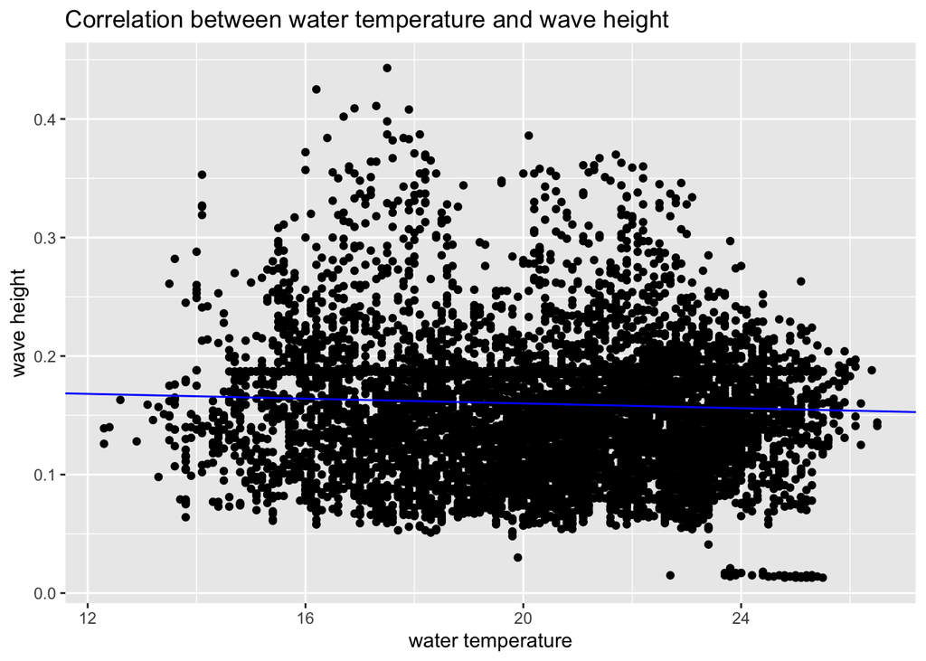

```r
beach_line = beach1 %>% mutate(pred = (water_temp*slope) + intercept)  %>% mutate(resid = resid)

beach_line %>% ggplot(aes(x = water_temp, y = wave_height)) +
  geom_point() +
  geom_abline(aes(slope = slope, intercept =intercept), color = "blue")+
  xlab("water temperature") +
  ylab("wave height") +
  ggtitle("Correlation between water temperature and wave height")
```

### Interpretation

This graph shows that the linear regression model has a weak and negative correlation. A lot of the points are far off from the predicted value from the line. Thus this shows the linear regression model fail to fit into the relationship between water temperature and wave height.

### Residual Graph

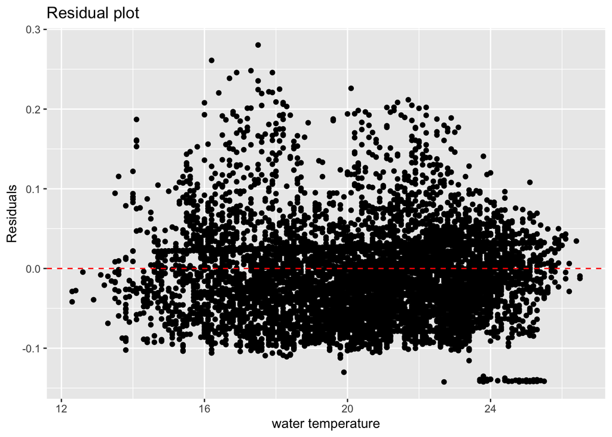

```r
beach_line %>% ggplot(aes(x = water_temp, y = resid))+
  geom_point() +
  xlab("water temperature") +
  ylab("Residuals") +
  geom_hline(aes(yintercept=0), color="red", linetype = "dashed") +
  ggtitle("Residual plot")
```

## Correlation bewteen ater Temperature and Turbidity

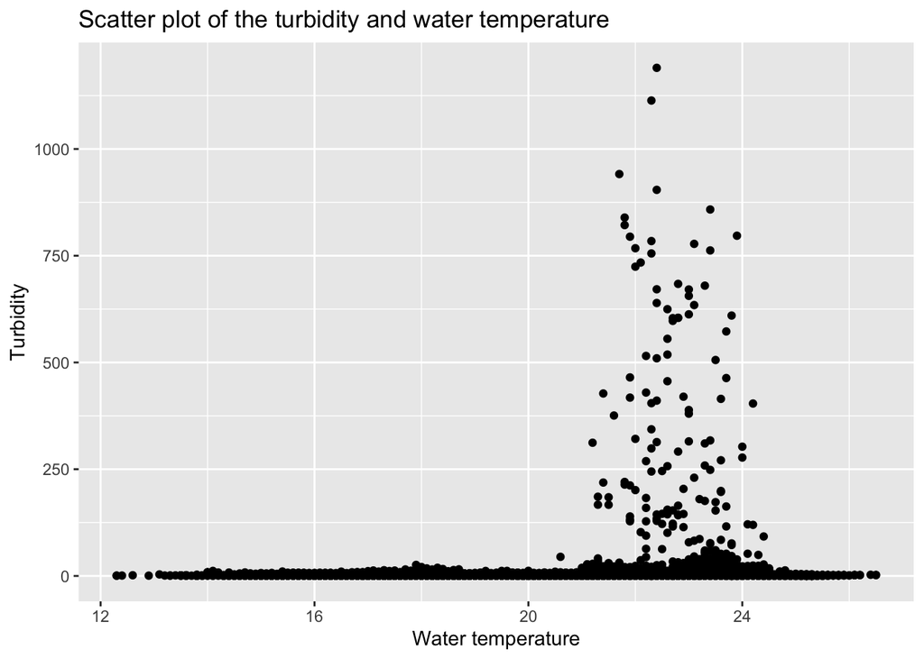

```r
beach1 %>% ggplot(aes(x = water_temp, y = turbidity)) +
  geom_point() +
  ggtitle("Scatter plot of the turbidity and water temperature") +
  xlab("Water temperature") +
  ylab("Turbidity")
```

## Interpretation

From this graph, we could see that the scale of turbidity seems to increase in a log scale. Thus we take the apply the log scale on it.

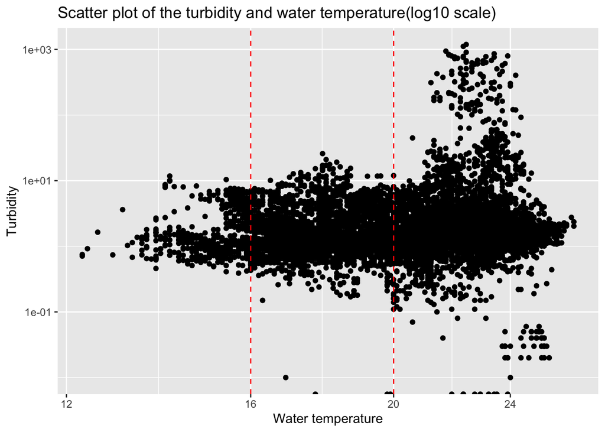

```r
beach1 %>% ggplot(aes(x = water_temp, y = turbidity)) +
  geom_point() +
  scale_y_log10() +
  scale_x_log10() +
  geom_vline(xintercept = c(16,20), color = "red", linetype = "dashed") +
  xlab("Water temperature") +
  ylab("Turbidity") +
  ggtitle("Scatter plot of the turbidity and water temperature(log10 scale)")
```

## Interpretation

From this graph, we could see that by divided the graph into three segements. We could see that there is a possible correlation between water temperature and turbidity in the fisrt segement. Thus we filter out water temperature less than 16 to look closely at the first segment.

```r
beach_mod = beach1 %>% filter(water_temp < 16)
turb_lm = lm(log10(turbidity)~log10(water_temp), data = beach_mod)
cf_turb = coef(turb_lm)
slope_turb = cf_turb[2]
intercept_turb = cf_turb[1]
resid_turb = residuals(turb_lm)
summary(turb_lm)
```

```
##
## Call:
## lm(formula = log10(turbidity) ~ log10(water_temp), data = beach_mod)
##
## Residuals:
##      Min       1Q   Median       3Q      Max
## -0.68649 -0.27092 -0.07696  0.26701  0.97169
##
## Coefficients:
##                   Estimate Std. Error t value Pr(>|t|)
## (Intercept)        -4.2945     0.8381  -5.124 4.27e-07 ***
## log10(water_temp)   3.8231     0.7117   5.372 1.19e-07 ***
## ---
## Signif. codes:  0 '***' 0.001 '**' 0.01 '*' 0.05 '.' 0.1 ' ' 1
##
## Residual standard error: 0.341 on 504 degrees of freedom
## Multiple R-squared:  0.05415,    Adjusted R-squared:  0.05227
## F-statistic: 28.85 on 1 and 504 DF,  p-value: 1.194e-07
```

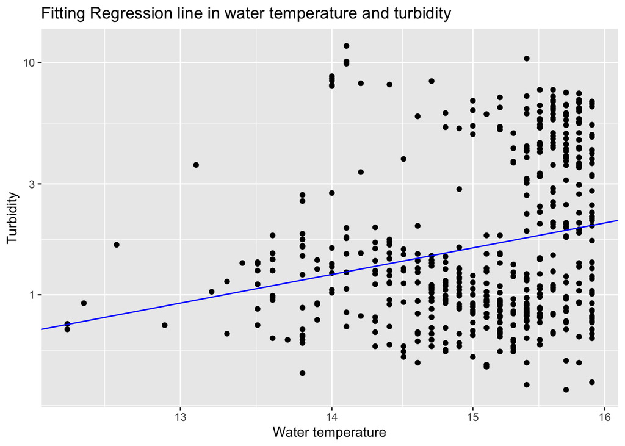

```r
beach_mod %>% ggplot(aes(x = water_temp, y = turbidity)) +
  geom_point() +
  geom_abline(aes(slope = slope_turb, intercept =intercept_turb), color = "blue")+
  xlab("Water temperature") +
  ylab("Turbidity") +
  ggtitle("Fitting Regression line in water temperature and turbidity")+
  scale_y_log10() +
  scale_x_log10()
```

### Interpretation

There is weak a positive correlation between water temperature and turbidity when water temperature is 12 to 16 degree.

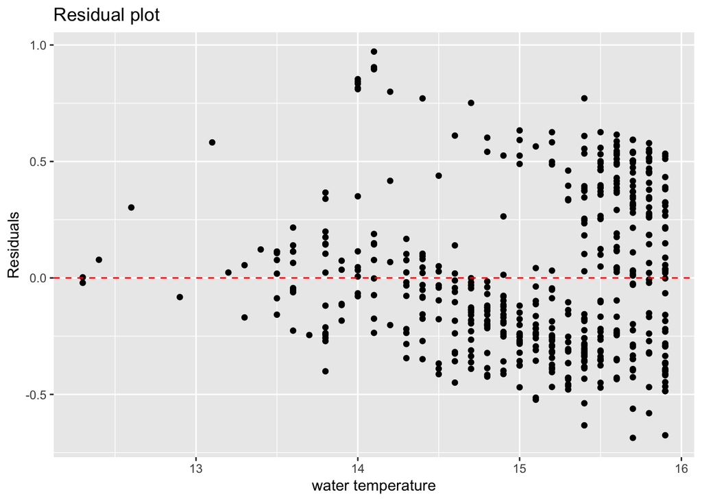

```r
beach_mod = beach_mod %>% mutate(resid = resid_turb)

beach_mod %>% ggplot(aes(x = water_temp, y = resid))+
  geom_point() +
  xlab("water temperature") +
  ylab("Residuals") +
  geom_hline(aes(yintercept=0), color="red", linetype = "dashed") +
  ggtitle("Residual plot")
```

## References

[^1]

[^1]: Primary Data Source: https://data.cityofchicago.org/d/qmqz-2xku, Secondary Data Source: https://data.world/cityofchicago/beach-water-quality-automated-sensors